# TI_Analysis

Petra Borovska

25 června 2020

## General Set Up

### Cleaning

clean environment and console

```r
cat("\014")
```

```r
rm(list = ls())
```

# Overview

1. Dataset handling: set up
2. Looking at the data
3. Descriptive Stats
4. Model specification
5. Data normalization/standardization
6. Outlier handling
7. Exclusion criteria
8. Assumption ANOVA
9. Assumptions lm
10. Unbalanced data
11. Post hoc

### 1. Dataset handling: set up

*replace the pilot data*

```r
## loading clean data in long format

## long format, clean, not subset
tr_tot_trim = read.csv(here::here("outputFiles_R", "tr_tot_trim.csv"))
ts_tot_trim = read.csv(here::here("outputFiles_R", "ts_tot_trim.csv"))

## subests
df_inf_prem_ts = read.csv(here::here("outputFiles_R", "df_inf_prem_ts.csv"))
df_deg_ts = read.csv(here::here("outputFiles_R", "df_deg_ts.csv"))
df_prem_middle_ts_wide_each = read.csv(here::here("outputFiles_R", "df_prem_middle_ts_wide_each.csv"))
df_prem_middle_ts_wide_avg = read.csv(here::here("outputFiles_R", "df_prem_middle_ts_wide_avg.csv"))


## simulated data
myData = read.csv(here::here("outputFiles_R", "myData.csv"))
```

### Data prep for pilot

Subseting pilot data, so I get 4 wake and 4 sleep participants with premise and inference collapsed over 1 deg and 2 deg

Datasets:  
pilot data = *ts_first_selected*  
simulated data = *myData*

```r
## selecting participants, so it's balanced in conditions
ts_first_selected =
        df_inf_prem_ts %>%
        filter(
                participant == "7" | participant == "8" | participant == "18" |
                        participant == "19" | participant == "17" | participant == "15" |
                        participant == "20" | participant == "21"
        )

## change to factors
ts_first_selected =
        ts_first_selected %>%
        mutate(
                pairType = as_factor(pairType),
                participant = as_factor(participant),
                condition = as_factor(condition)
                )

head(ts_first_selected)
```

```
##    pairType condition participant trBlocks tot  n      prop
## 1   premise     sleep           7        5  48 50 0.9600000
## 2 inference     sleep           7        5  30 30 1.0000000
## 3   premise     sleep           8        5  48 50 0.9600000
## 4 inference     sleep           8        5  30 30 1.0000000
## 5   premise      wake          15        5  46 50 0.9200000
## 6 inference      wake          15        5  29 30 0.9666667
```

**Simulated data**  
More sensitive data. Used in simulation loop and also possible to use for assumptions checks, as a contrast to pilot data.

```r
head(myData)
```

```
##   subject condition  pairType      perf
## 1       1     sleep inference 1.0000000
## 2       2     sleep inference 1.0000000
## 3       3     sleep inference 0.9051961
## 4       4     sleep inference 0.8786871
## 5       5     sleep inference 0.4941468
## 6       6     sleep inference 0.9017642
```

**The main models**

*Pilot*

```r
aov_pilot <- aov_ez(
        "participant",
        "prop",
        data = ts_first_selected,
        between = c("condition"),
        within = c("pairType"),
        type = 3
)
```

```
## Contrasts set to contr.sum for the following variables: condition
```

```r
summary(aov_pilot)
```

```
##
## Univariate Type III Repeated-Measures ANOVA Assuming Sphericity
##
##                     Sum Sq num Df Error SS den Df  F value    Pr(>F)
## (Intercept)        10.4437      1  0.57477      6 109.0206 4.525e-05 ***
## condition           0.0477      1  0.57477      6   0.4976    0.5070
## pairType            0.0220      1  0.16677      6   0.7916    0.4079
## condition:pairType  0.0000      1  0.16677      6   0.0001    0.9923
## ---
## Signif. codes:  0 '***' 0.001 '**' 0.01 '*' 0.05 '.' 0.1 ' ' 1
```

*Simulation data*

```r
aov_simDat <- aov_ez(
        "subject",
        "perf",
        data = myData,
        between = c("condition"),
        within = c("pairType"),
        type = 3
)
```

```
## Converting to factor: condition
```

```
## Contrasts set to contr.sum for the following variables: condition
```

### 2. Looking at the data

Basic data overview. How the measure look like.

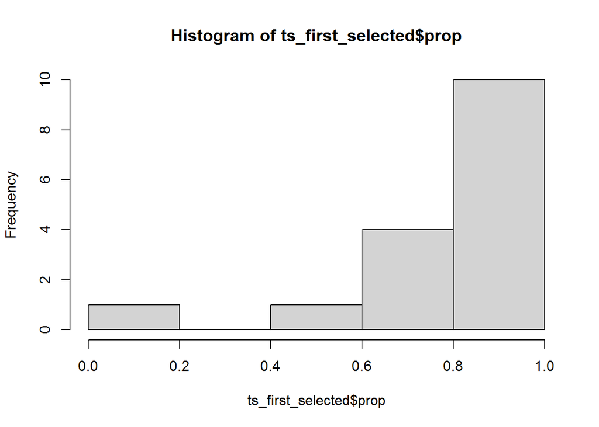

```r
## histogram of DV
hist(ts_first_selected$prop)
```

```r
## basic summary of the dataset
summary(ts_first_selected)
```

```
##       pairType condition  participant    trBlocks           tot
##  premise  :8   sleep:8   7      :2    Min.   : 5.000   Min.   : 4.00
##  inference:8   wake :8   8      :2    1st Qu.: 5.000   1st Qu.:27.50
##                          15     :2    Median : 7.000   Median :30.50
##                          17     :2    Mean   : 6.875   Mean   :32.69
##                          18     :2    3rd Qu.: 7.250   3rd Qu.:43.75
##                          19     :2    Max.   :11.000   Max.   :49.00
##                          (Other):4
##        n           prop
##  Min.   :30   Min.   :0.1333
##  1st Qu.:30   1st Qu.:0.7100
##  Median :40   Median :0.8900
##  Mean   :40   Mean   :0.8079
##  3rd Qu.:50   3rd Qu.:0.9700
##  Max.   :50   Max.   :1.0000
##
```

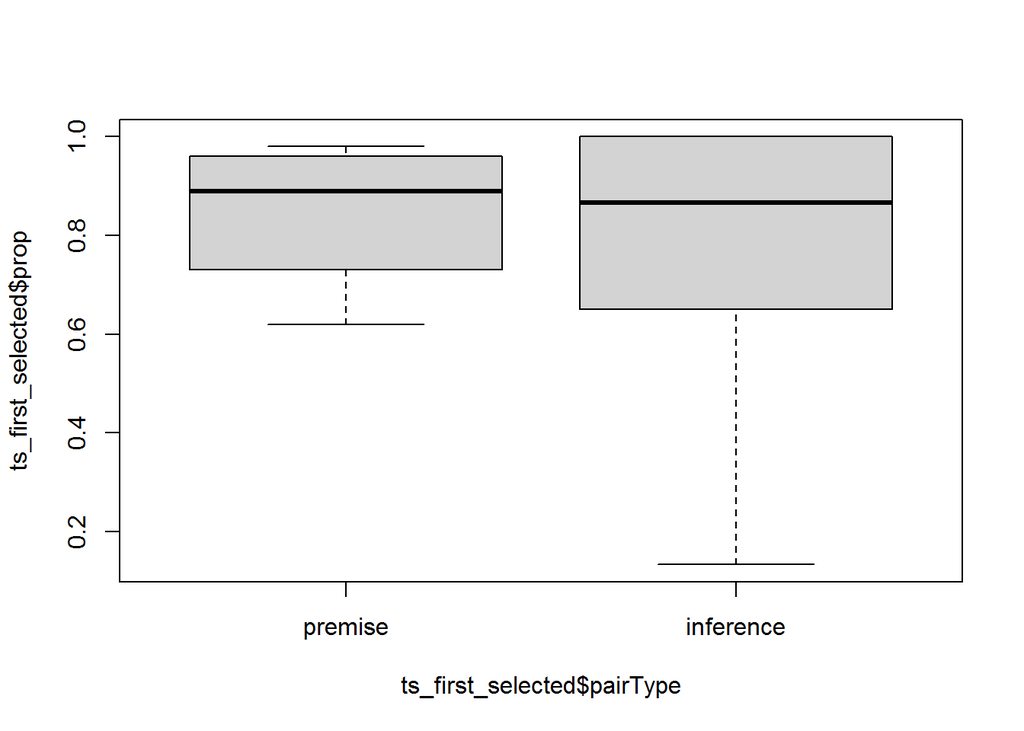

```r
## basic boxplots
boxplot(ts_first_selected$prop ~ ts_first_selected$pairType)
```

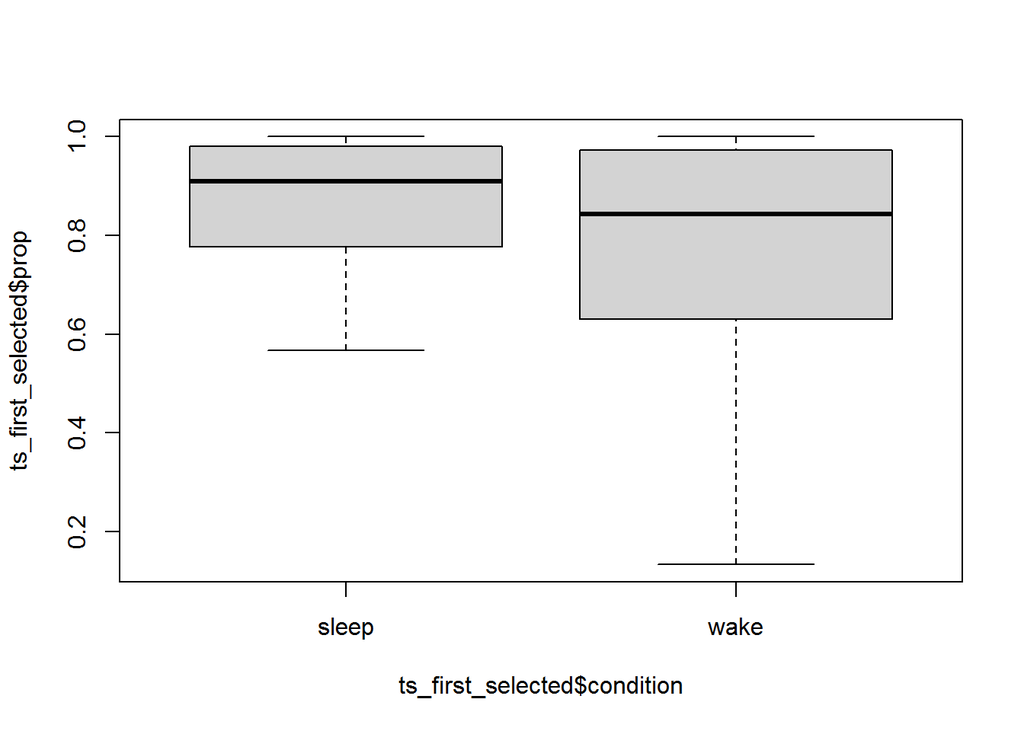

```r
boxplot(ts_first_selected$prop ~ ts_first_selected$condition)
```

### 3. Descriptive Stats

Looking at mean, sd, median, standar errors, min, max and ci's

```r
## group by condition and pairType to see mean, median, sd, IQR
pilot_groupSummary =
        ts_first_selected %>%
        group_by(
                condition,
                pairType
        ) %>%
        dplyr::summarise(
                n = n(),
                mean = mean(prop),
                median = median(prop),
                sd = sd(prop),
                sem = sd/sqrt(n),
                min = min(prop),
                max = max(prop)
                ) %>%
        mutate(
                lower.ci = mean - qt(1 - (0.5 / 2), n - 1) * sem,
                upper.ci = mean + qt(1 - (0.5 / 2), n - 1) * sem
        ) %>%
        ungroup()
pilot_groupSummary
```

```
## # A tibble: 4 x 11
##   condition pairType     n  mean median     sd    sem   min   max lower.ci
##   <fct>     <fct>    <int> <dbl>  <dbl>  <dbl>  <dbl> <dbl> <dbl>    <dbl>
## 1 sleep     premise      4 0.900  0.910 0.0712 0.0356 0.82   0.96    0.873
## 2 sleep     inferen~     4 0.825  0.867 0.213  0.107  0.567  1       0.743
## 3 wake      premise      4 0.79   0.78  0.187  0.0933 0.62   0.98    0.719
## 4 wake      inferen~     4 0.717  0.867 0.402  0.201  0.133  1       0.563
## # ... with 1 more variable: upper.ci <dbl>
```

```r
## look at SE, CI <- but it does not look good
pilot_CI = summarySEwithin(
        ts_first_selected,
        measurevar = "prop",
        withinvars = "pairType",
        betweenvars = "condition",
        idvar = "participant",
        na.rm = FALSE,
        conf.interval = .95
        )
```

### Main Plot

```
## No summary function supplied, defaulting to `mean_se()`
```

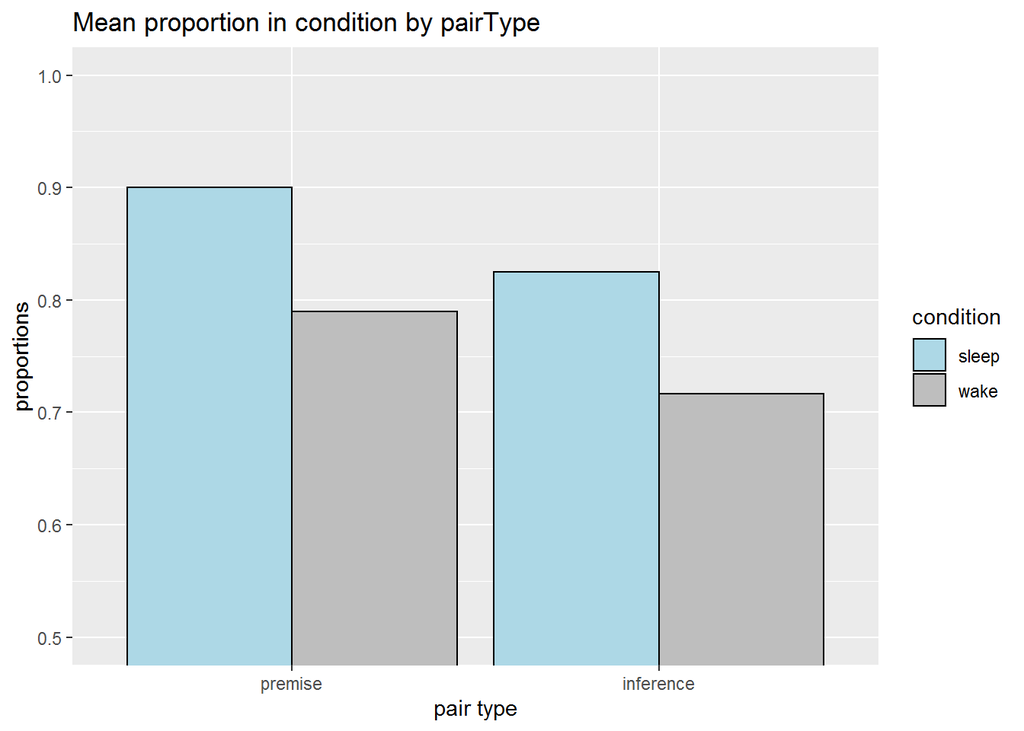

```r
## ploting the proportion over pair type and condition - adjust based on what to look at
pilot_Plot = ggplot(data = ts_first_selected, aes(x=pairType, y=prop))
pilot_Plot +
        stat_summary(geom = "bar", position="dodge", colour = 'black',
                     aes(fill=condition)) +
        scale_fill_manual(values = c("lightblue", "grey")) +
        labs(title='Mean proportion in condition by pairType', x='pair type',
             y='proportions', fill='condition') +
        coord_cartesian(ylim=c(0.5, 1))
```

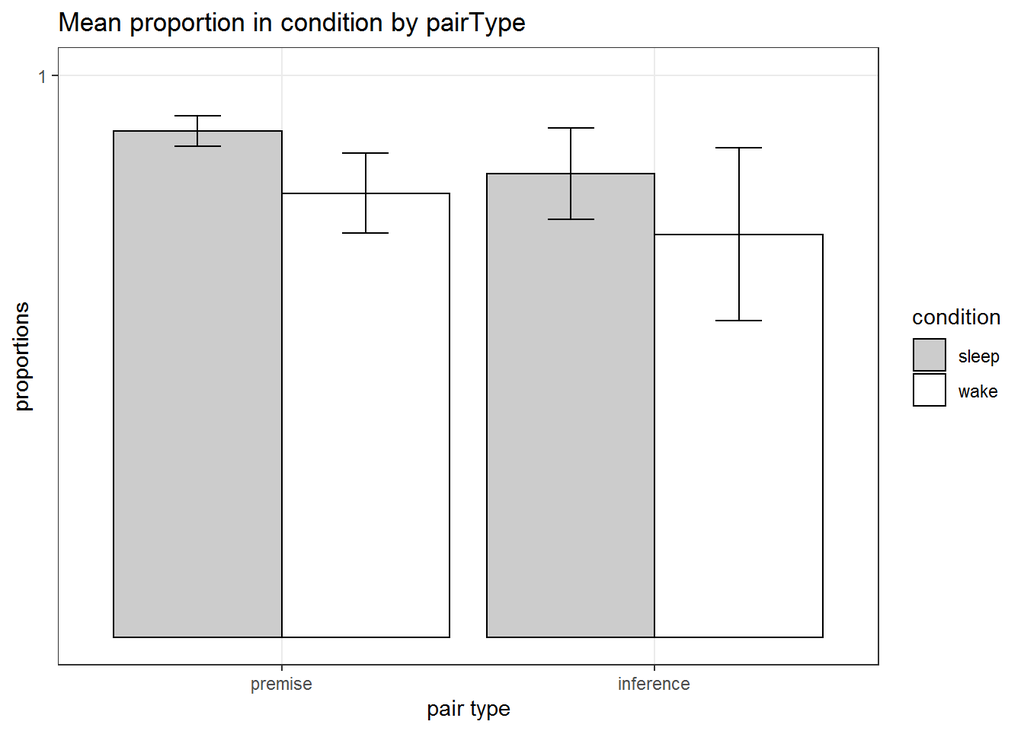

```r
## with CIs
ggplot(pilot_groupSummary, aes(x=pairType, y=mean, fill=condition)) +
    geom_bar(position=position_dodge(.9), colour="black", stat="identity") +
    geom_errorbar(position=position_dodge(.9), width=.25, aes(ymin=lower.ci, ymax=upper.ci)) +
    coord_cartesian(ylim=c(0,1)) +
    scale_fill_manual(values=c("#CCCCCC","#FFFFFF")) +
        labs(title='Mean proportion in condition by pairType', x='pair type',
             y='proportions', fill='condition') +
    scale_y_continuous(breaks=seq(1:100)) +
    theme_bw() +
    geom_hline(yintercept=38)
```

### 4. Model specification

- ANOVA mixed: within + between
- correlation: simple linear regression (premise pair performance predicts middle inference pair performace)
1. basic model - performance - 2 x 2  
   *Performance on inference pairs will be significantly higher in sleep condition vs. wake.*

   ```
   model = aov_ez(
               "subject",
               "perf",
               data = myData,
               between = c("condition"),
               within = c("pairType")
       )
   ```

   ```
   DV performance
   IV condition = sleep, wake
   IV pairType = premise, inference
   ```

2. condition and separation - 2 x 2  
   *Performance on inference pairs will be significantly higher in sleep condition vs. wake.* *Performance on 2 degree pairs increase after sleep vs. non sleep*

   ```
   model = aov_ez(
               "subject",
               "perf",
               data = myData,
               between = c("condition"),
               within = c("separation")
       )
   ```

   ```
   DV performance
   IV condition = sleep, wake
   IV separation = 1 deg, 2 deg
   ```

   <- situation when premise equal in both conditions
3. performance and separation - 2 x 3  
   *Performance on inference pairs will be significantly higher in sleep condition vs. wake.* *Performance on 2 degree pairs increase after sleep vs. non sleep*

   ```
   model = aov_ez(
               "subject",
               "perf",
               data = myData,
               between = c("condition"),
               within = c("pairType_Sep")
       )
   ```

   ```
   DV performance
   IV condition = sleep, wake
   IV pairType_Sep = premise, 1 deg, 2 deg
   ```

   <- situation when premise not equal in both condition
4. response time  
   *Response time decreases after sleep vs. non sleep*

   ```
   model = aov_ez(
               "subject",
               "rt",
               data = myData,
               between = c("condition"),
               within = c("pairType")
       )
   ```

5. response time and separation - 2 x 2  
   *Response time decreases after sleep vs. non sleep* *Response time is higher in more distant pairs vs. less distant pairs*

   ```
   model = aov_ez(
               "subject",
               "rt",
               data = myData,
               between = c("condition"),
               within = c("separation")
       )
   ```

   ```
   DV response time
   IV condition = sleep, wake
   IV separation = 1 deg, 2 deg
   ```

   <- situation when premise equal in both conditions
6. response time and separation - 2 x 3  
   *Response time decreases after sleep vs. non sleep* *Response time is higher in more distant pairs vs. less distant pairs*

   ```
   model = aov_ez(
               "subject",
               "rt",
               data = myData,
               between = c("condition"),
               within = c("pairType_Sep")
       )
   ```

   ```
   DV response time
   IV condition = sleep, wake
   IV pairType_Sep = premise, 1 deg, 2 deg
   ```

   <- situation when premise not equal in both condition
7. correlation  
   *Premise pairs correlate with inference pairs*

performance on middle premise pairs with middle inference pairs

```
    bivariate regression analysis
            y(inferencePair) = b*x(premisePair) + a

    oneDeg B>C + C>D       = B>D
    oneDeg C>D + D>E       = C>E
    twoDeg B>C + C>D + D>E = BE
```

### 5. Data standardization/normalization

*Definitions* [Link](https://towardsai.net/p/data-science/how-when-and-why-should-you-normalize-standardize-rescale-your-data-3f083def38ff)

**Rescaling** = a vector means to add or subtract a constant and then multiply or divide by a constant, as you would do to change the units of measurement of the data, for example, to convert a temperature from Celsius to Fahrenheit.

```
scale(x, center = TRUE, scale = TRUE)
```

**Normalization** = a vector most often means dividing by a norm of the vector. It also often refers to rescaling by the minimum and range of the vector, to make all the elements lie between 0 and 1 thus bringing all the values of numeric columns in the dataset to a common scale.

```
normalize(x, method = "standardize", range = c(0, 1), margin = 1L, on.constant = "quiet")
```

**Standardization** = a vector most often means subtracting a measure of location and dividing by a measure of scale. For example, if the vector contains random values with a Gaussian distribution, you might subtract the mean and divide by the standard deviation, thereby obtaining a “standard normal” random variable with mean 0 and standard deviation 1.

```
scale(x, center = TRUE, scale = TRUE)
```

** Probably using normalization when the data are not normally distributed.**

### 6. Outlier handling

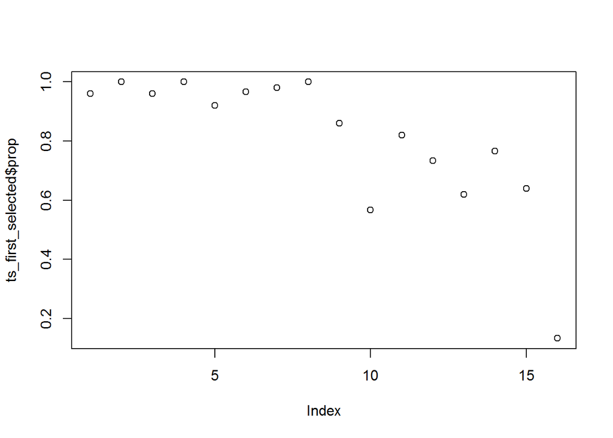

```r
## first outlook of outliers - simple plots
plot(ts_first_selected$prop)
```

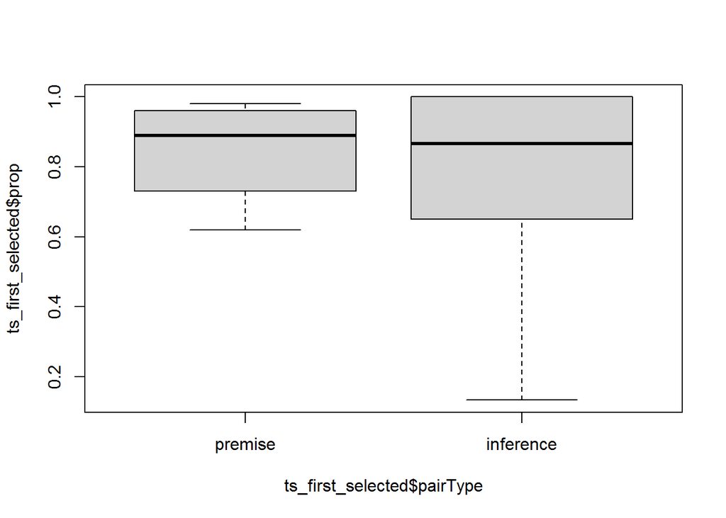

```r
boxplot(ts_first_selected$prop ~ ts_first_selected$pairType)
```

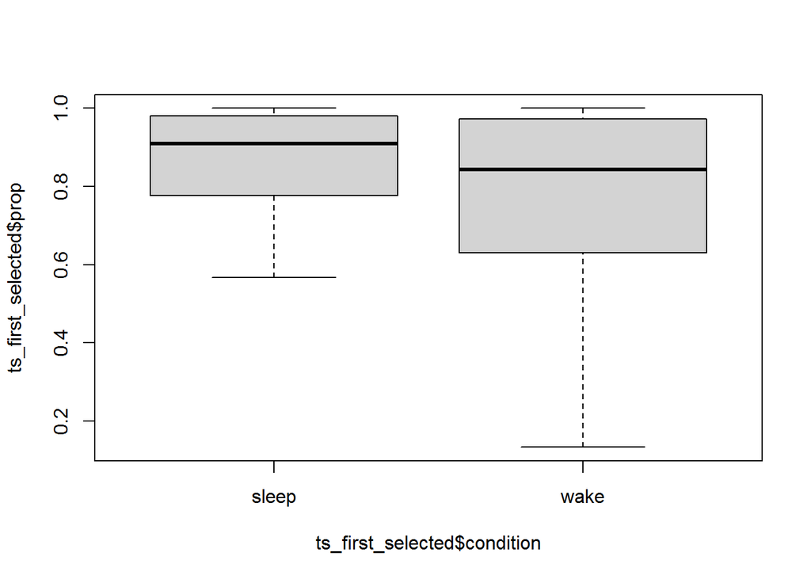

```r
boxplot(ts_first_selected$prop ~ ts_first_selected$condition)
```

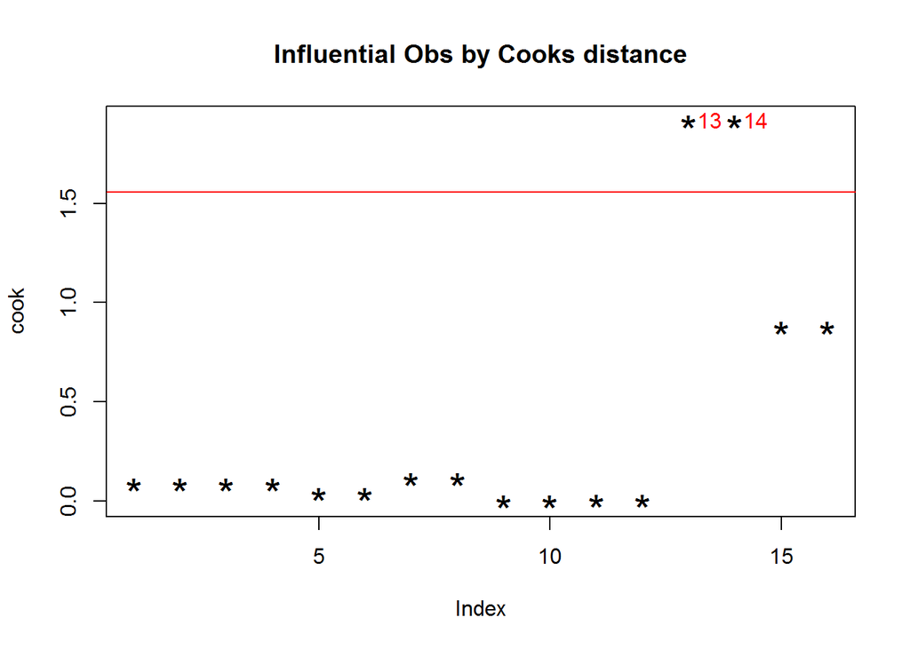

```r
## cook distance for looking at outliers
## if the distance is for times higher from the mean, than consider to be outlier
outL = lm(prop ~ ., data = ts_first_selected)
cook = cooks.distance(outL)
meanCook = mean(cook)

## observation that have a cook's distance greater than 4 times the mean - influential
plot(cook, pch="*", cex=2, main="Influential Obs by Cooks distance")  # plot cook's distance
abline(h = 4*mean(cook, na.rm=T), col="red")  # add cutoff line
text(x=1:length(cook)+1, y=cook, pos=2, labels=ifelse(cook>4*mean(cook, na.rm=T),names(cook),""), col="red")  # add labels, gives me back number of outlier
```

```r
## extract the rows with influential cases
influential <- as.numeric(names(cook)[(cook > 4*mean(cook, na.rm=T))])
influential
```

```
## [1] 13 14
```

```r
ts_first_selected[influential, ]
```

```
##     pairType condition participant trBlocks tot  n      prop
## 13   premise      wake          20        8  31 50 0.6200000
## 14 inference      wake          20        8  23 30 0.7666667
```

```r
## use also test for most extreme observation based on the given model
car::outlierTest(outL)
```

```
## No Studentized residuals with Bonferroni p < 0.05
## Largest |rstudent|:
##     rstudent unadjusted p-value Bonferroni p
## 14 -4.208585          0.0084197      0.13472
```

### 7. Exclusion Criteria

Will be specified after children pilot.  
For now:  
more than 30 blocks of training.  
outliers ?? how to handle still open

### 8. Assumptions for ANOVA

1. independence of observations - except of within condition
2. dv should be at interval level - continuous  
   <- question how to handle exactly proportion
3. homogeneity of variance - homoscedasticity:  
   - visual check - fitted ~ residuals <- no pattern  
   - Levene test <- leveneTest(dv ~ condition) - should not be sign (null - the groups had equal population variance)
4. normality of residuals - visual check - plot residuals `hist(x=seq(from=min(residuals(twoway)), to=max(residuals(twoway)), length.out=100)lines(x=x, y=dnorm(x, mean=0,sd=sd(residuals(twoway)))))`  
   - the residuals should float evently around 0, not creating any obvious pattern - QQ plot: **qqnorm(residuals())**, **qqline(residuals())***  
   - kolmogorov-smirnov test, *ks.test()* - should not be sign  
   <- are both from same distribution  
   - shapiro-wilk test, *shapiro.test()* - should not be sign <- whether normal distributed
5. sphericity - just for within anova  
   = homogeneity of variance between in conditions that are compared to each other  
   = in within conditions - those should have similar variances, vialoation is serious for repeated measures, so then later when comparison between 1 deg, 2 deg, prem - if it's gonna be done, still not sure, maybe 1 deg and 2 deg alone enough  
   <- not necessary when only two way comparisons - then there is not much to be compared to, comparison possible only with 3 and more groups

### 9. Assumptions for lm

test the asumptios for poisson glm:

1. balanced design - same number in each condition (that should be fine) <- problems with complete separation
2. multicolliearity (relatedness of predictors) vif(model) <- values around 1 should be fine, more - tend to be colinear z transform - not for binary - low counts also in question
3. check on influencial cases - Cooks's distance <- max(cooks.distance(model)) inspect visually, otherwise if > 4/N or 4/(N-k-1), where a N - number of observations, k - number of explanatory variables ols_plot_cooksd_chart() <- plot data - dfbetas - model stability <- max(abs(dfbeta(model))) <- inspect range of coefficients: cbind(coefficients(model), coefficients(model)+t(apply(X=dfbeta(model), MARGIN=2, FUN=range))) plot data - ols_plot_dfbetas(model) values bigger than 1 suspicious
4. overdispersion - if sd of the response larger than model assume, response is overdispersed <- sd of coefficients too small, increase type I error - disperisontest(model) <- should be around 1, over 1 overdispersed - arising due to missing important predictor - package(AER)
5. full null model comparison - full model comparing to null model: full = glm(dv ~ cond1 * cond2) null = glm(dv ~ 1) anova(full, null, test='Chisq') - effect of interaction - full to reduced reduced = glm(dv ~ cond1 + cond2) anova(full, reduced, test='Chisq') - test the main effect to reduced to further reduced reduced2 = glm(dv ~ cond1) anova(full, reduced2) - effect of condition reduced3 = glm(dv ~ cond2) anova(full, reduced3)
6. get confidence intervals confint(model) cbind(coefficients(full), confint(object=full))

**Homogeneity of variance - homoscedasticity** Looking at fitted values against residuals. No pattern should be visible.  
Consider number of observation when looking at the plot. With pilot data probably strange patterns due to small number of observations.

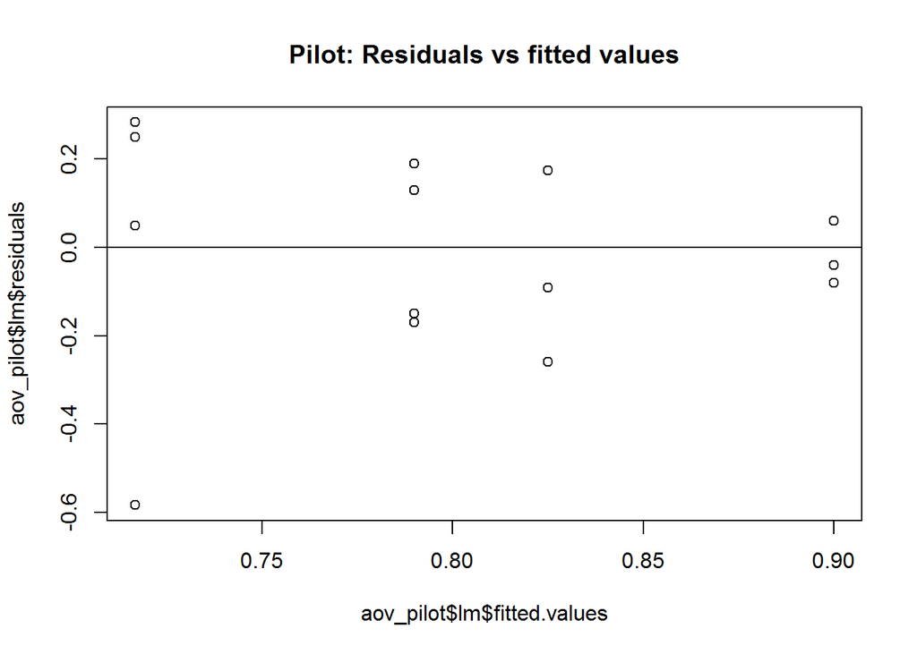

```r
## VISUAL CHECK

## two ways where to get residuals and fitted values

## from aov_ez
plot(aov_pilot$lm$residuals ~ aov_pilot$lm$fitted.values, main="Pilot: Residuals vs fitted values")
abline(h=0)
```

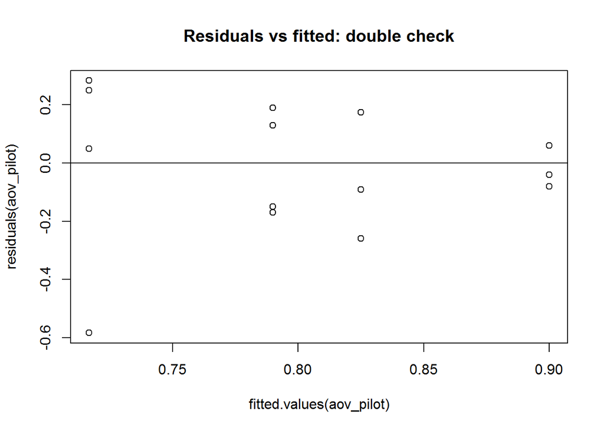

```r
## residual, fitted.values commands <- same plots
plot(residuals(aov_pilot) ~ fitted.values(aov_pilot), main="Residuals vs fitted: double check")
abline(h=0)
```

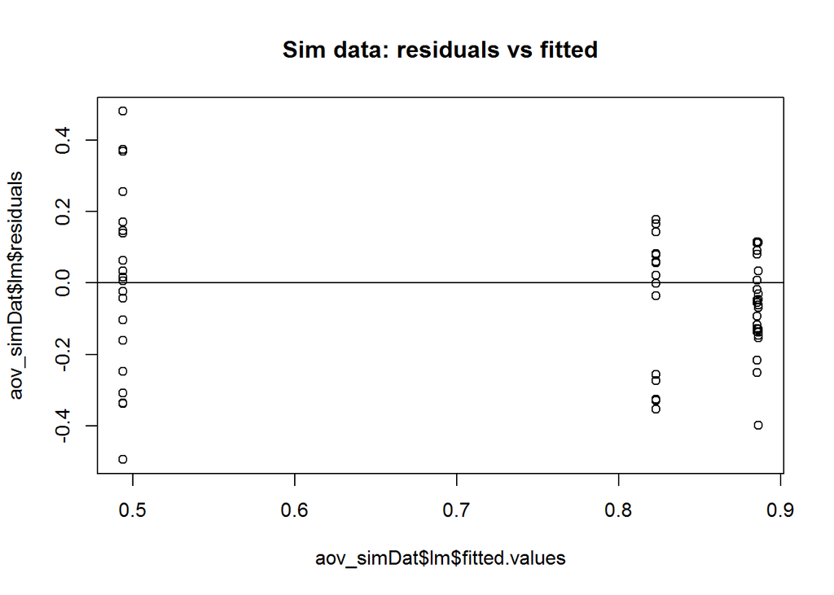

```r
## look at simulated data residuals vs fitted
plot(aov_simDat$lm$residuals ~ aov_simDat$lm$fitted.values, main="Sim data: residuals vs fitted")
abline(h=0)
```

```r
## FORMAL TESTS

## levenetest
test_levene(aov_pilot, center = mean) ## not significant is good
```

```
## Levene's Test for Homogeneity of Variance (center = center)
##       Df F value Pr(>F)
## group  1   2.199 0.1886
##        6
```

```r
## running the model only with condition and specifying an error, should be same as above
btw1 = aov_car(
        prop ~ condition + Error(participant), data = ts_first_selected
)
## levene test only on between condition - which is condition
test_levene(btw1)
```

```
## Levene's Test for Homogeneity of Variance (center = center)
##       Df F value Pr(>F)
## group  1   2.199 0.1886
##        6
```

**Normality**

```r
## VISUAL CHECKS

## look at raw values of fitted values, residuals and actual data
cbind(fitted.values(aov_pilot), residuals(aov_pilot), ts_first_selected$prop)
```

```
##         [,1]        [,2]      [,3]
## 1  0.7166667  0.25000000 0.9600000
## 2  0.7900000  0.13000000 1.0000000
## 3  0.7166667  0.28333333 0.9600000
## 4  0.7900000  0.19000000 1.0000000
## 5  0.8250000 -0.25833333 0.9200000
## 6  0.9000000 -0.04000000 0.9666667
## 7  0.8250000 -0.09166667 0.9800000
## 8  0.9000000 -0.08000000 1.0000000
## 9  0.7166667  0.05000000 0.8600000
## 10 0.7900000 -0.17000000 0.5666667
## 11 0.7166667 -0.58333333 0.8200000
## 12 0.7900000 -0.15000000 0.7333333
## 13 0.8250000  0.17500000 0.6200000
## 14 0.9000000  0.06000000 0.7666667
## 15 0.8250000  0.17500000 0.6400000
## 16 0.9000000  0.06000000 0.1333333
```

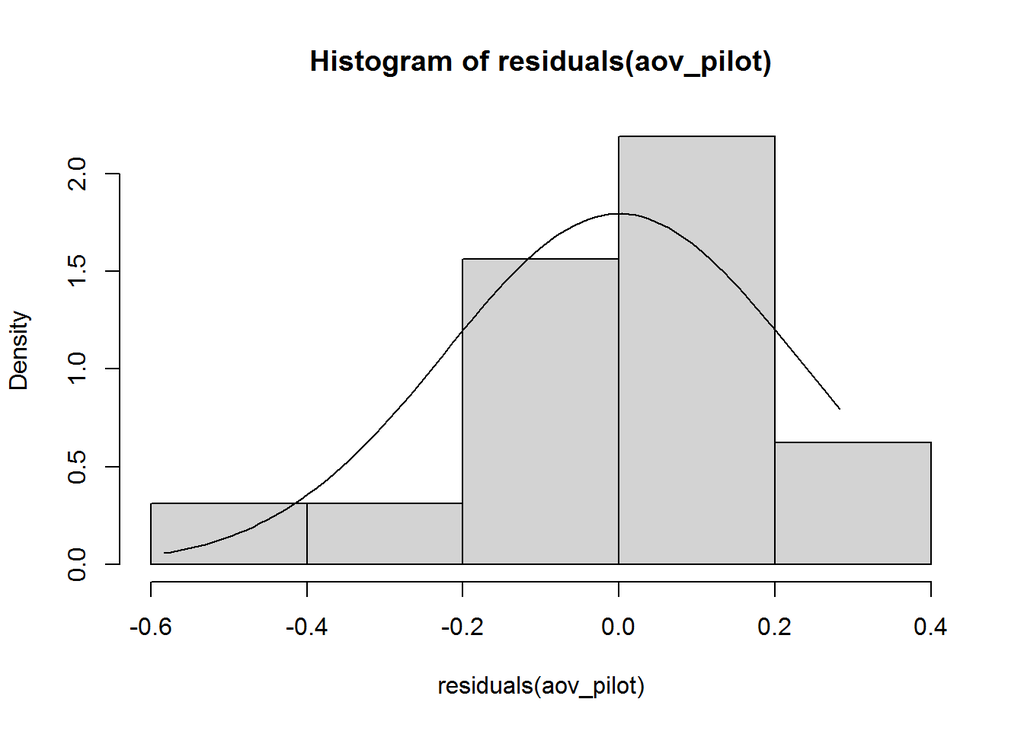

```r
## visual check
hist(residuals(aov_pilot), probability = T)
## add line
x = seq(from=min(residuals(aov_pilot)), to=max(residuals(aov_pilot)), length.out = 100)
lines(x=x, y=dnorm(x, mean = 0, sd=sd(residuals(aov_pilot))))
```

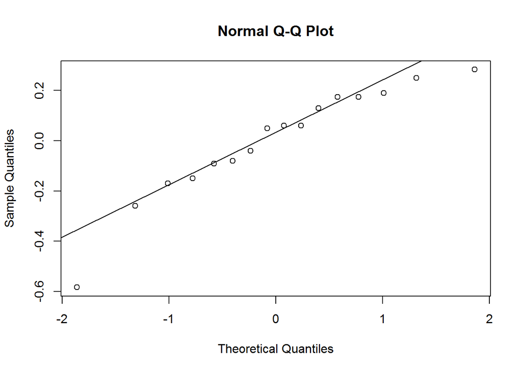

```r
## look at linearity of residuals
qqnorm(residuals(aov_pilot))   ## should follow the line
qqline(residuals(aov_pilot))
```

```r
## FORMAL CHECKS

## shapiro wilk test
shapiro.test(residuals(aov_pilot)) ## should not be sign
```

```
##
##  Shapiro-Wilk normality test
##
## data:  residuals(aov_pilot)
## W = 0.91803, p-value = 0.1568
```

### 10. Unbalanced design

Weighted vs. unweighted means:

weighted: - taking into account the correlation between the factors with different sample sizes  
- sum of both levels divided by total number of values  
- type I anova

unweighted means:  
- does not take into account the correlation  
- average of the individual group means, summing the means of each level / total number of levels  
- type III anova

different sample size problematic for homogeneity of variance when big - with one way  
with two way - problems because the inequality affects both levels and then hard to distinguish between the level effects

> However, if the sample size differences arose from random assignment, and there just happened to be more observations in some cells than others, then one would want to estimate what the main effects would have been with equal sample sizes and, therefore, weight the means equally. With the means weighted equally, there is no main effect of B, the result obtained with Type III sums of squares.

[Link](http://onlinestatbook.com/2/analysis_of_variance/unequal.html)

### 11. Post hoc test

lsmeans multiple comparison between groups, if balanced then the means should match reality

commands

compar = lsmeans(anova_model, specs = c("betweenCondition")) or possibly also within contrast(compar, method = "pairwise")

<- adjust for bonferroni correct for multiple comparisons - it correct for more hypothesis in use, with relation to alpha level - which then becomes more strict

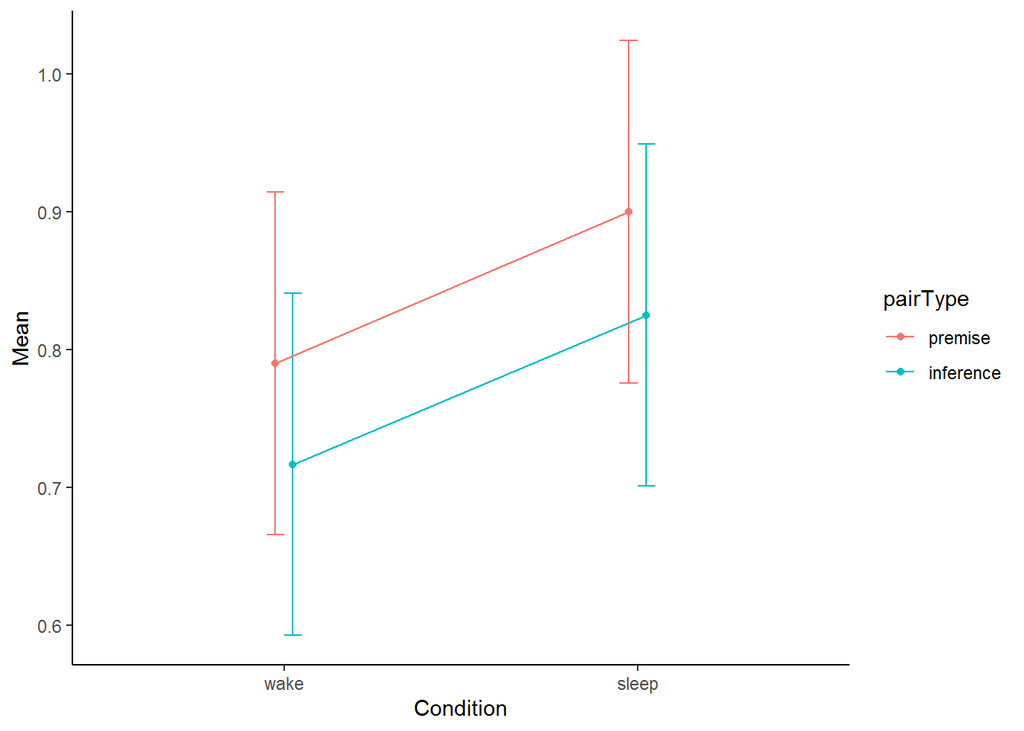

```r
## lsmeans
grid = lsmeans(aov_pilot, specs=c("condition", "pairType"))


grid_plot = as.data.frame(summary(grid))
pd <- position_dodge(0.1)
g4 <- ggplot(grid_plot, aes(x=factor(condition, level=c('wake', 'sleep')), y=lsmean,group=pairType,colour=pairType))+
 geom_errorbar(aes(ymin=lsmean-SE, ymax=lsmean+SE), width=.1,position=pd) +
   geom_line(position=pd)+
   geom_point(position=pd)+theme_classic()+
        labs(x="Condition", y="Mean")
print(g4)
```

```r
## pairwise comparisons
compar = lsmeans(aov_pilot, specs = c("condition"))
```

```
## NOTE: Results may be misleading due to involvement in interactions
```

```r
## pairwise
contrast(compar, method = "pairwise")   ## adjusted for tukey method
```

```
##  contrast     estimate    SE df t.ratio p.value
##  sleep - wake    0.109 0.155  6 0.705   0.5070
##
## Results are averaged over the levels of: pairType
```

```r
## bonferroni
contrast(compar, method = "pairwise", adjust = "bonferroni")
```

```
##  contrast     estimate    SE df t.ratio p.value
##  sleep - wake    0.109 0.155  6 0.705   0.5070
##
## Results are averaged over the levels of: pairType
```

```r
## all pairwise comparison within each level of pairType
meansGrid2 = lsmeans(aov_pilot, ~condition|pairType)

compar_2 = contrast(meansGrid2, method="pairwise")
summary(compar_2)
```

```
## pairType = premise:
##  contrast     estimate    SE   df t.ratio p.value
##  sleep - wake    0.110 0.176 9.21 0.626   0.5466
##
## pairType = inference:
##  contrast     estimate    SE   df t.ratio p.value
##  sleep - wake    0.108 0.176 9.21 0.616   0.5526
```

```r
## adjustment
summary(compar_2, by=NULL, adjus="holm")
```

```
##  contrast     pairType  estimate    SE   df t.ratio p.value
##  sleep - wake premise      0.110 0.176 9.21 0.626   1.0000
##  sleep - wake inference    0.108 0.176 9.21 0.616   1.0000
##
## P value adjustment: holm method for 2 tests
```

```r
sum_aov_pilot = summary(aov_pilot)
```

### Linear Regression

```r
## looking at data set for lm
head(df_prem_middle_ts_wide_avg)
```

```
##   participant condition midd_prem inference
## 1           6      wake 0.5000000 0.1000000
## 2           7     sleep 0.9666667 1.0000000
## 3           8     sleep 0.9333333 1.0000000
## 4           9      wake 0.4666667 0.3666667
## 5          11      wake 0.6000000 0.8333333
## 6          15      wake 0.8666667 0.9666667
```

```r
pairType_lm = lm(inference ~ midd_prem*condition, data = df_prem_middle_ts_wide_avg)
summary(pairType_lm)
```

```
##
## Call:
## lm(formula = inference ~ midd_prem * condition, data = df_prem_middle_ts_wide_avg)
##
## Residuals:
##     Min      1Q  Median      3Q     Max
## -0.5323 -0.1188  0.0770  0.1758  0.3017
##
## Coefficients:
##                         Estimate Std. Error t value Pr(>|t|)
## (Intercept)              -0.3646     1.1512  -0.317    0.760
## midd_prem                 1.4134     1.3559   1.042    0.328
## conditionwake             0.4562     1.2049   0.379    0.715
## midd_prem:conditionwake  -0.5932     1.4604  -0.406    0.695
##
## Residual standard error: 0.3024 on 8 degrees of freedom
## Multiple R-squared:  0.3747, Adjusted R-squared:  0.1403
## F-statistic: 1.598 on 3 and 8 DF,  p-value: 0.2646
```